# Week 11 Day 3 homework

```r
library(cluster)
library(dendextend)
library(factoextra)
library(tidyverse)
library(janitor)
library(broom)
```

```r
customer_data <- read_csv("data/mall_customers.csv") %>%
  clean_names() %>%
  column_to_rownames("customer_id") %>%
  rename(annual_income = annual_income_k,
         spending_score = spending_score_1_100)
```

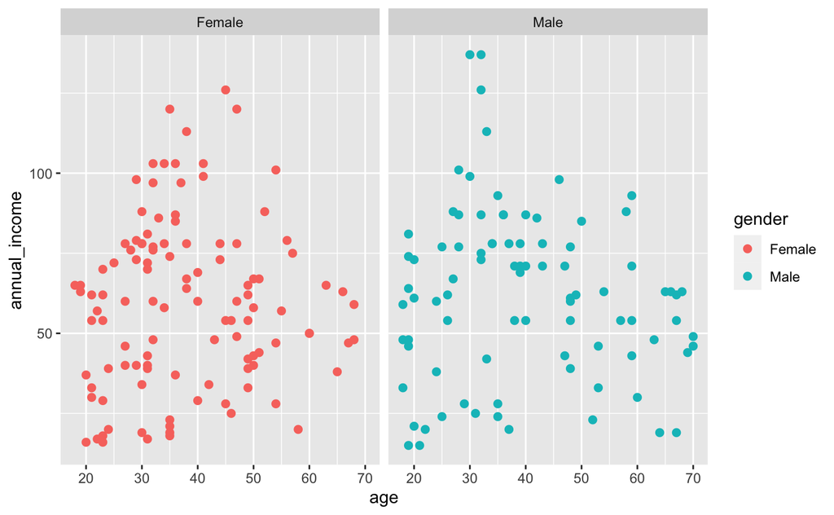

```r
customer_data %>%
  ggplot() +
  aes(x = age, y = annual_income, colour = gender) +
  geom_point(size = 2) +
  facet_grid(~ gender)
```

Comment: For females, looks like there are groupings - between ages 25-40 with annual income between 50k and 75k - between 20 and 35 with annual income less than 50k For males, looks like there are groupings - between 20 and 40 with low annual income - between 25 and 50 with annual income c75k

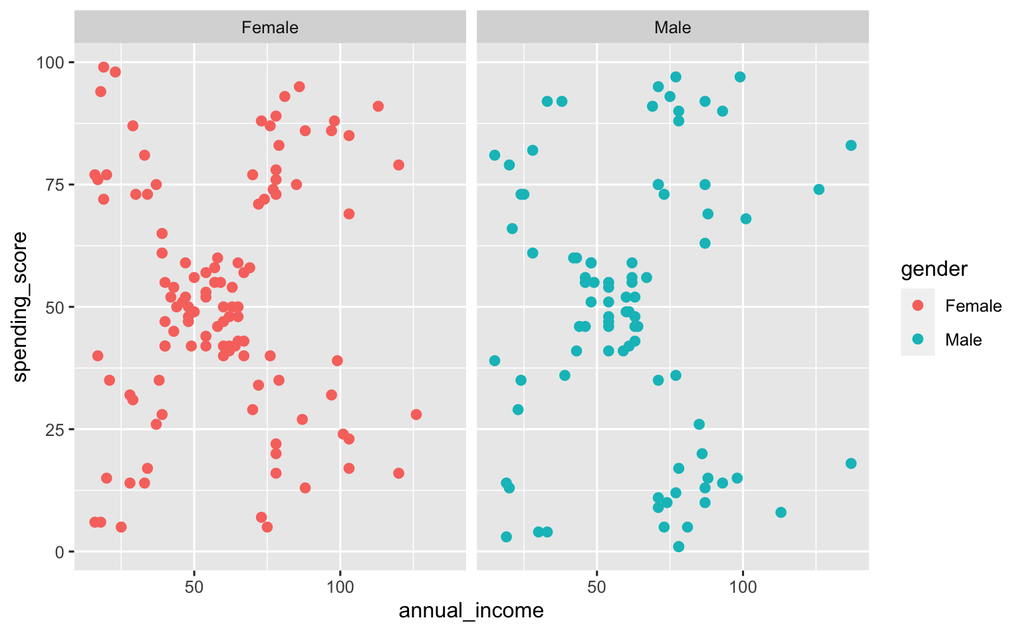

```r
customer_data %>%
  ggplot() +
  aes(x = annual_income, y = spending_score, colour = gender) +
  geom_point(size = 2) +
  facet_grid(~ gender)
```

Comment: For females, looks like there are five groupings radiating out from a central group where nnual_income c50k and spending score c50 Other four groups then become low income/low score, low income/high score, high income/low score, high income/high score

Similar pattern for males although perhaps not as distinct for the lower income groups

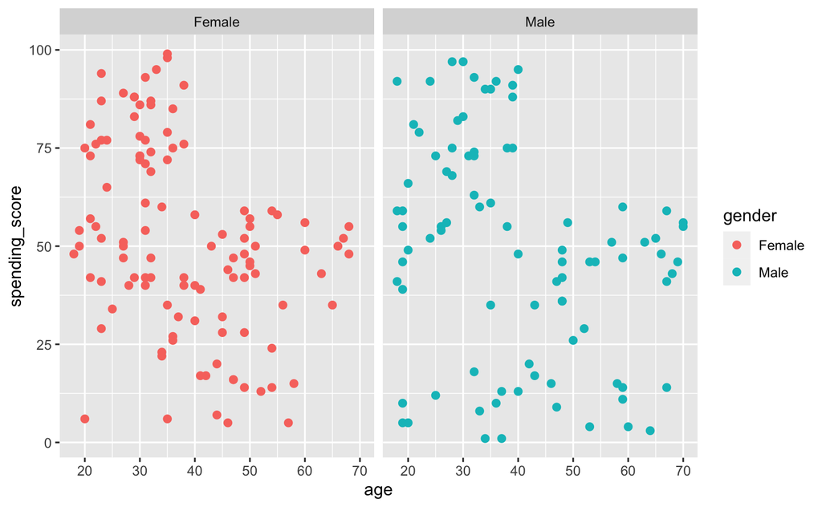

```r
customer_data %>%
  ggplot() +
  aes(x = age, y = spending_score, colour = gender) +
  geom_point(size = 2) +
  facet_grid(~ gender)
```

Comment: For both females and males looks like there is a grouping of under 40s with high spending score

```r
customer_income_spend <- customer_data %>%
  select(annual_income, spending_score)
```

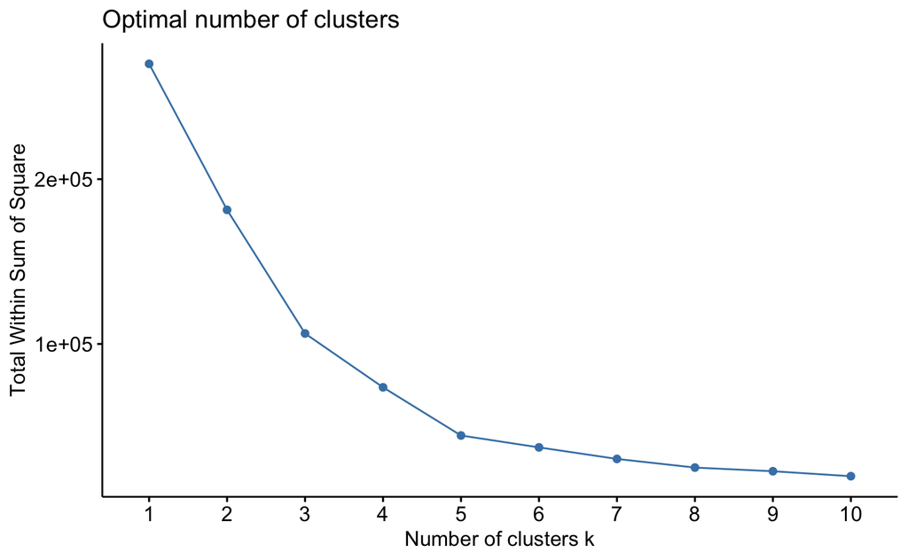

```r
fviz_nbclust(customer_income_spend,
             kmeans,
             method = "wss",
             nstart = 25)
```

Looks like the "elbow’ occurs at k = 5

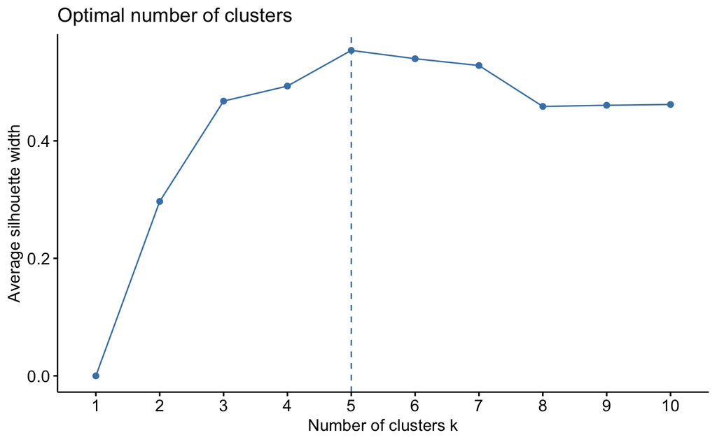

```r
fviz_nbclust(customer_income_spend,
             kmeans,
             method = "silhouette",
             nstart = 25)
```

Again, maximum occurs at k = 5

```
Clustering k = 1,2,..., K.max (= 10): .. done
Bootstrapping, b = 1,2,..., B (= 100)  [one "." per sample]:
.................................................. 50
.................................................. 100
```

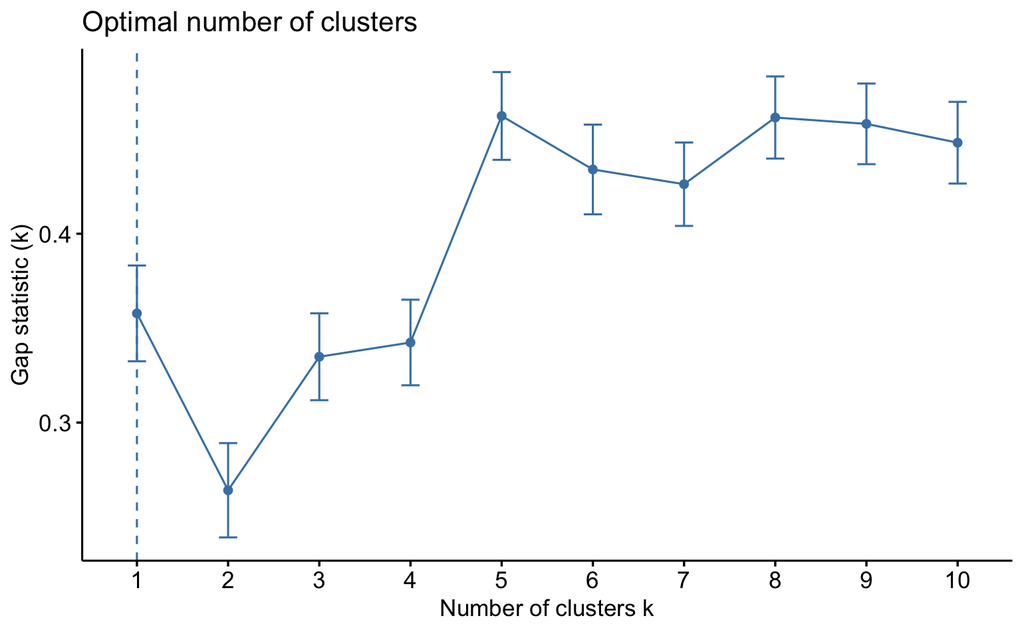

```r
fviz_nbclust(customer_income_spend,
             kmeans,
             method = "gap_stat",
             nstart = 25,
             k.max = 10)
```

```r
clusters <- kmeans(customer_income_spend, centers = 5, nstart = 25)
```

```r
clustered_customer <- augment(clusters, customer_data)
```

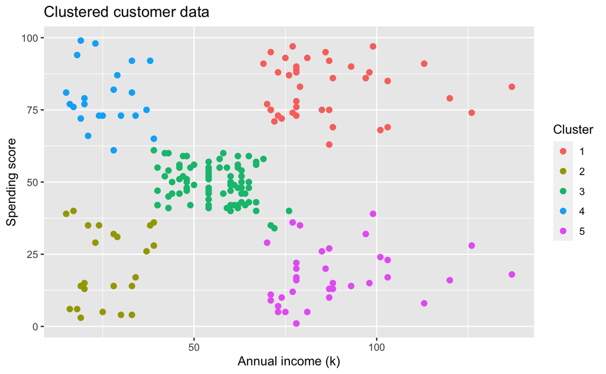

```r
clustered_customer %>%
  ggplot() +
  aes(x = annual_income, y = spending_score, colour = .cluster) +
  geom_point(size = 2) +
  labs(title = "Clustered customer data",
       x = "Annual income (k)",
       y = "Spending score",
       colour = "Cluster")
```

The clustering seems to be a good fit for this data and confirms the comments made in the initial data exploration.